# Rendu TP2 - Alexis PLESSIER

PARTIE I:

Exercice 1 :

Chargement des bibliothèques.

```r
library(factoextra)
library(FactoMineR)
library(gtsummary)
library(markdown)
library(readxl)
```

Exercice 2 :

Chargement et premier traitement de la base de données :

```r
Deca20 <- read_excel("C:/Users/Alexis/Downloads/Deca20.xlsx")
View(Deca20)
dat20=Deca20[-seq(2,nrow(Deca20),by=3),];
dat20=as.data.frame(dat20);
colnames(dat20)[2];
```

```
[1] "Athlète"
```

```r
colnames(dat20)[2]="Athlete";
```

Exercice 3.1 :

Création de deux dataframes différentes : Une pour les performance et l’autre pour les points attribués.

```r
dat20Point=dat20[seq(1,nrow(dat20),by=2),]
dat20Perf=dat20[-seq(1,nrow(dat20),by=2),]
dat20Point=as.data.frame(dat20Point)
dat20Perf=as.data.frame(dat20Perf)
View(dat20Point) ; View(dat20Perf)
```

Exercice 3.2 :

Ajout de données manquantes pour les performances.

```r
dat20Perf[,"Athlete"]=dat20Point[,"Athlete"]
dat20Perf[,"Pays"]=dat20Point[,"Pays"]
dat20Perf[,"Total"]=dat20Point[,"Total"]
dat20Perf$Rang=1 :nrow(dat20Perf)
dat20Point$Rang=1 :nrow(dat20Perf)
```

Exercice 3.3 :

Redéfini le nom des lignes des deux tableaux.

```r
dim(dat20Perf)
```

```
[1] 23 14
```

```r
dimnames(dat20Perf);rownames(dat20Perf)
```

```
[[1]]
 [1] "2"  "4"  "6"  "8"  "10" "12" "14" "16" "18" "20" "22" "24" "26"
[14] "28" "30" "32" "34" "36" "38" "40" "42" "44" "46"

[[2]]
 [1] "Rang"     "Athlete"  "Pays"     "Total"    "100 m"    "Long."
 [7] "Poids"    "Haut."    "400 m"    "110 m h." "Disque"   "Perche"
[13] "Jav."     "1 500 m"

 [1] "2"  "4"  "6"  "8"  "10" "12" "14" "16" "18" "20" "22" "24" "26"
[14] "28" "30" "32" "34" "36" "38" "40" "42" "44" "46"
```

```r
rownames(dat20Perf)=as.character(dat20Perf$Athlete)
rownames(dat20Point)=as.character(dat20Perf$Athlete)
```

Exercice 4 :

Suppression des lignes avec des données manquantes

```r
dat20Perf=na.omit(dat20Perf)
dat20Point=na.omit(dat20Point)
View(dat20Perf) ;View(dat20Point)
```

Exercice 5.1 :

```r
dat20Perf0=dat20Perf
dat20Perf=dat20Perf[,-(1 :4)]
dat20Point0=dat20Point
dat20Point=dat20Point[,-(1 :4)]
```

Exercice 5.2 :

Affichage et modification des valeurs de type chr en valeurs numériques.

```r
str(dat20Point) ;str(dat20Perf)
```

```
'data.frame':   22 obs. of  10 variables:
 $ 100 m   : chr  "1066" "933" "1013" "935" ...
 $ Long.   : chr  "1123" "935" "970" "886" ...
 $ Poids   : chr  "777" "794" "758" "826" ...
 $ Haut.   : chr  "822" "878" "906" "794" ...
 $ 400 m   : chr  "934" "800" "994" "897" ...
 $ 110 m h.: chr  "1045" "987" "964" "971" ...
 $ Disque  : chr  "843" "830" "754" "776" ...
 $ Perche  : chr  "880" "972" "910" "941" ...
 $ Jav.    : chr  "790" "937" "695" "876" ...
 $ 1 500 m : chr  "738" "660" "685" "709" ...
'data.frame':   21 obs. of  10 variables:
 $ 100 m   : chr  "10.12" "10.68" "10.34" "10.67" ...
 $ Long.   : chr  "8.24" "7.50" "7.64" "7.30" ...
 $ Poids   : chr  "14.80" "15.07" "14.49" "15.59" ...
 $ Haut.   : chr  "2.02" "2.08" "2.11" "1.99" ...
 $ 400 m   : chr  "47.48" "50.31" "46.29" "48.25" ...
 $ 110 m h.: chr  "13.46" "13.90" "14.08" "14.03" ...
 $ Disque  : chr  "48.67" "48.08" "44.38" "45.46" ...
 $ Perche  : chr  "4.90" "5.20" "5.00" "5.10" ...
 $ Jav.    : chr  "63.44" "73.09" "57.12" "69.10" ...
 $ 1 500 m : chr  "4:31.08" "4:43.17" "4:39.19" "4:35.54" ...
```

```r
dat20Perf=apply( dat20Perf,2,as.numeric)
dat20Point=apply(dat20Point,2,as.numeric)
```

```
Warning in apply(dat20Point, 2, as.numeric) :
  NAs introduced by coercion
Warning in apply(dat20Point, 2, as.numeric) :
  NAs introduced by coercion
Warning in apply(dat20Point, 2, as.numeric) :
  NAs introduced by coercion
Warning in apply(dat20Point, 2, as.numeric) :
  NAs introduced by coercion
Warning in apply(dat20Point, 2, as.numeric) :
  NAs introduced by coercion
Warning in apply(dat20Point, 2, as.numeric) :
  NAs introduced by coercion
```

```r
str(dat20Point) ;str(dat20Perf)
```

```
 num [1:22, 1:10] 1066 933 1013 935 992 ...
 - attr(*, "dimnames")=List of 2
  ..$ : NULL
  ..$ : chr [1:10] "100 m" "Long." "Poids" "Haut." ...
 num [1:21, 1:10] 10.1 10.7 10.3 10.7 10.4 ...
 - attr(*, "dimnames")=List of 2
  ..$ : NULL
  ..$ : chr [1:10] "100 m" "Long." "Poids" "Haut." ...
```

Nous avons des warning car les tableaux possèdent les valeur : DNF, DNS ou encore NM, qui ne peut pas être converti en valeur numérique. Ceci va nous donner des NA que nous devrons enlever pour la suite. Les valeurs de performance du 1500m sont également inconvertible. Il y a également une erreur de virgule pour la Performance à la perche du 17eme participant que l’on peut corriger.

```r
dat20Perf[17,8] = 4.6
dat20Perfm1500=dat20Perf[,-10]
dat20Perfm1500=na.omit(dat20Perfm1500)
View(dat20Perfm1500)
```

Exercice 7 :

Analyse des données du DataFrame dat20Perfm1500.

```r
apply(dat20Perfm1500,2,mean)
```

```
    100 m     Long.     Poids     Haut.     400 m  110 m h.    Disque
10.775789  7.371579 14.780526  2.010526 48.704211 14.477368 45.973684
   Perche      Jav.
 4.926316 60.683158
```

```r
apply(dat20Perfm1500,2,median)
```

```
   100 m    Long.    Poids    Haut.    400 m 110 m h.   Disque   Perche
   10.69     7.36    14.80     2.02    48.89    14.48    46.38     4.90
    Jav.
   60.44
```

```r
apply(dat20Perfm1500,2,IQR)
```

```
   100 m    Long.    Poids    Haut.    400 m 110 m h.   Disque   Perche
   0.420    0.270    0.600    0.045    1.180    0.540    3.550    0.300
    Jav.
   6.405
```

```r
apply(dat20Perfm1500,2,function(x)quantile(x,0.1))
```

```
   100 m    Long.    Poids    Haut.    400 m 110 m h.   Disque   Perche
  10.412    7.030   13.978    1.960   47.368   14.004   42.314    4.600
    Jav.
  53.968
```

```r
apply(dat20Perfm1500,2,function(x)quantile(x,0.9))
```

```
   100 m    Long.    Poids    Haut.    400 m 110 m h.   Disque   Perche
  11.108    7.642   15.430    2.056   50.412   14.950   48.886    5.220
    Jav.
  69.592
```

Caractèristique de dispersion :

```r
apply(dat20Perfm1500,2,sd) #Ecart type
```

```
     100 m      Long.      Poids      Haut.      400 m   110 m h.
0.30674484 0.29065564 0.59725738 0.04801316 1.21759926 0.44956574
    Disque     Perche       Jav.
2.79126855 0.25131234 6.03054452
```

```r
CVx=apply(dat20Perfm1500,2,sd)/apply(dat20Perfm1500,2,mean)#Coefficient de Variation
CVx
```

```
     100 m      Long.      Poids      Haut.      400 m   110 m h.
0.02846611 0.03942922 0.04040840 0.02388089 0.02499988 0.03105300
    Disque     Perche       Jav.
0.06071448 0.05101426 0.09937757
```

Intervalle entre le 1er et dernier quartile :

```r
apply(dat20Perfm1500,2,function(x)quantile(x,0.75)) - apply(dat20Perfm1500,2,function(x)quantile(x,0.25))
```

```
   100 m    Long.    Poids    Haut.    400 m 110 m h.   Disque   Perche
   0.420    0.270    0.600    0.045    1.180    0.540    3.550    0.300
    Jav.
   6.405
```

Ces résultats signifient, par exmeple, qu’entre les 25% d’athlètes les moins bons au 100m et les 25% meilleurs, il y a une différence de 0.42 secondes. Ou encore une différence de 60 centimètres au lancé de Poids ou bien 6.405 mètres au lancé de Javelot.

Intervalle entre le 1er et le dernier décile :

```r
apply(dat20Perfm1500,2,function(x)quantile(x,0.9)) - apply(dat20Perfm1500,2,function(x)quantile(x,0.1))
```

```
   100 m    Long.    Poids    Haut.    400 m 110 m h.   Disque   Perche
   0.696    0.612    1.452    0.096    3.044    0.946    6.572    0.620
    Jav.
  15.624
```

Graphique 100m :

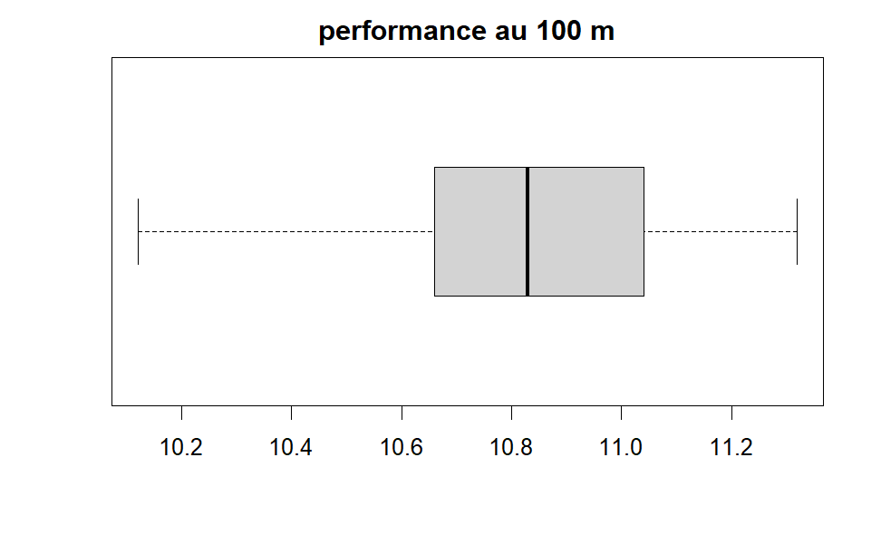

```r
colnames(dat20Perf)[1]="100m"
boxplot(dat20Perf[,"100m"],horizontal=T)
title(main="performance au 100 m")
```

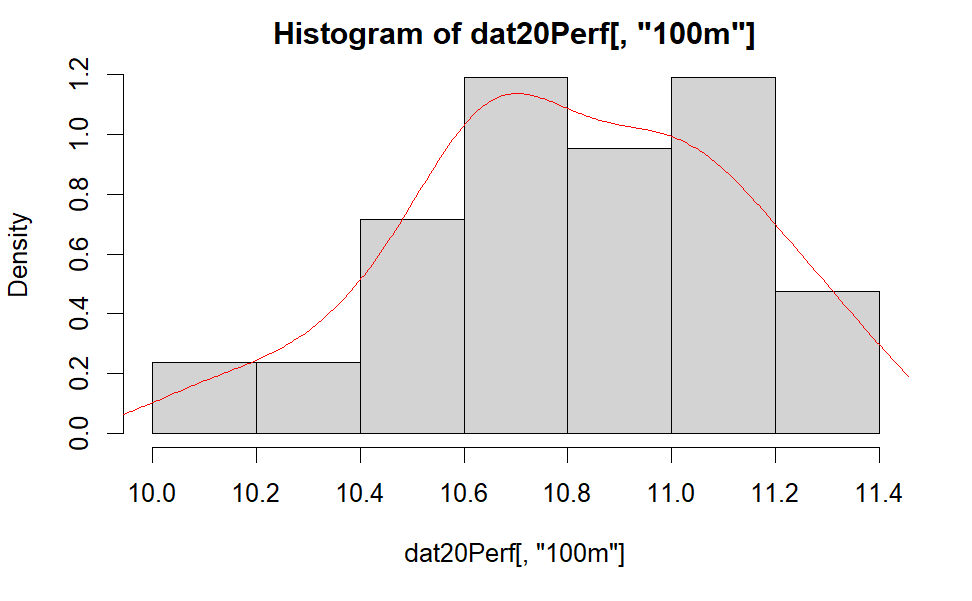

```r
hist(dat20Perf[,"100m"],prob=T)
lines(density(dat20Perf[,"100m"]),col= "red")
```

Histogramme : Distribution Non équilibrée, une grandee partie des athlètes ont un temps entre 10.6s et 11.2s.

Graphique Saut en Longueur :

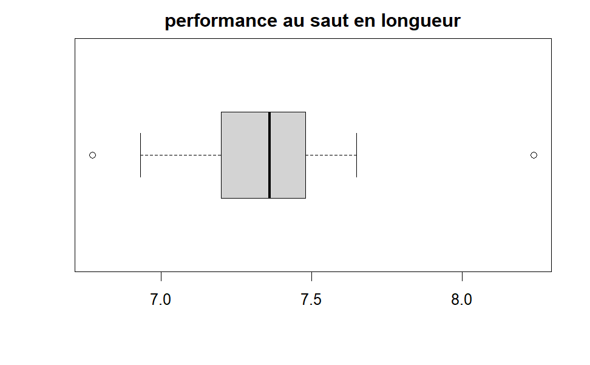

```r
colnames(dat20Perf)[2]="Long."
boxplot(dat20Perf[,"Long."],horizontal=T)
title(main="performance au saut en longueur")
```

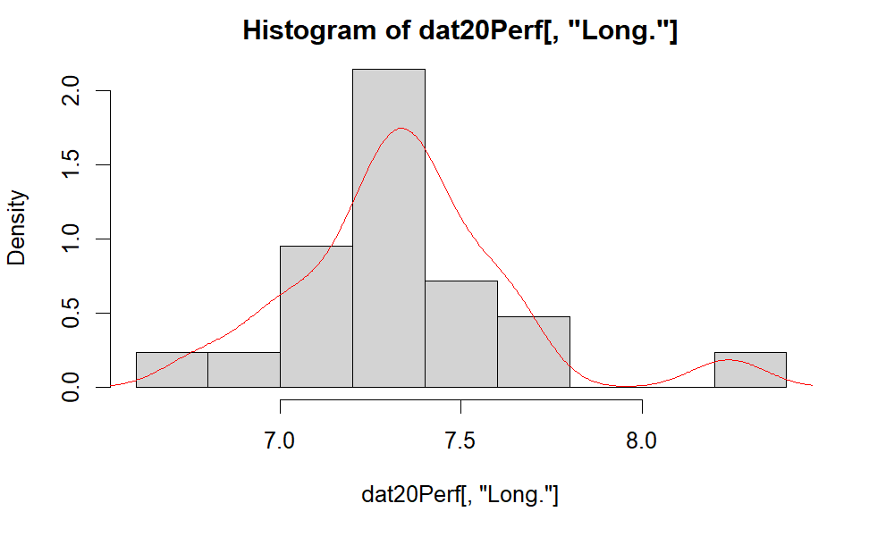

```r
hist(dat20Perf[,"Long."],prob=T)
lines(density(dat20Perf[,"Long."]),col= "red")
```

Histogramme : Distribution Non équilibrée (mais presque), une grandee partie des athlètes ont un saut entre 7.2m et 7.5m. On remarque également une valeur au dela de 8m qui pourrait faire penser à une erreur.

Graphique Lancé de Poids :

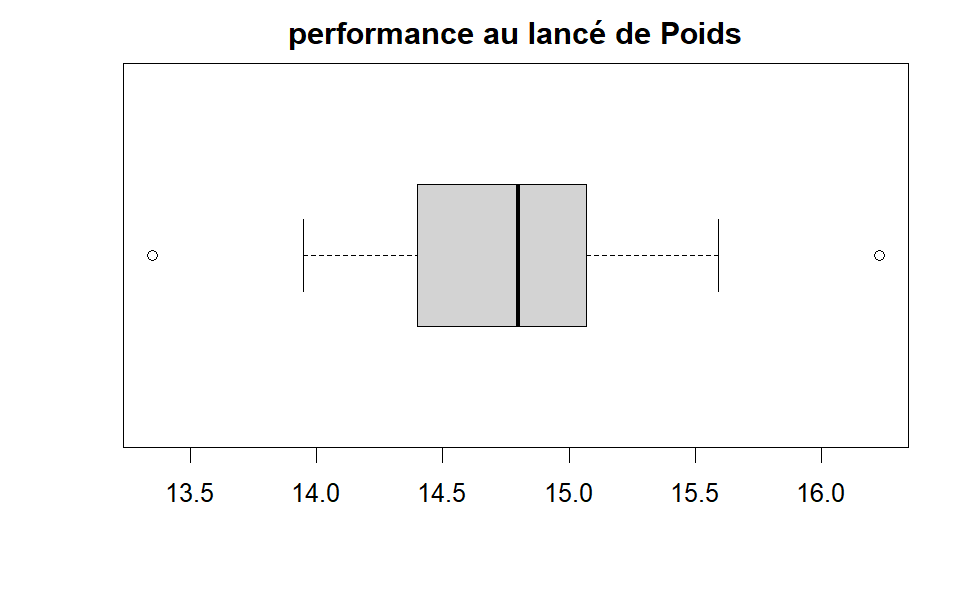

```r
colnames(dat20Perf)[3]="Poids"
boxplot(dat20Perf[,"Poids"],horizontal=T)
title(main="performance au lancé de Poids")
```

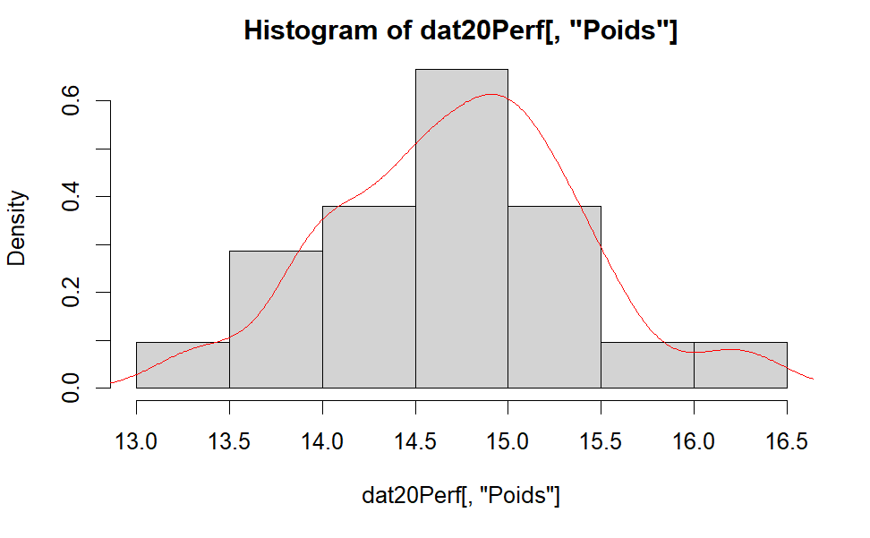

```r
hist(dat20Perf[,"Poids"],prob=T)
lines(density(dat20Perf[,"Poids"]),col= "red")
```

Histogramme : Distribution Non équilibrée (mais presque), une grandee partie des athlètes ont un lancé entre 14.2m et 15.2m.

PARTIE II :

Importation des données, transformation en DataFrame et gestion des noms de variables.

```r
datdon=scan("statlab.txt")
```

```
Read 2185 items
```

```r
datdon=matrix(datdon,ncol=19,byrow=T)
datdon=data.frame(datdon)
colnames(datdon)=c("sexenf","gsenf","tenf_n","penf_n", "tenf_10","penf_10",
"gsmere","agem_n","pmere_n","consm_n","tmere",
"pmere_10", "consm_10","agep_n", "consp_n","tpere","ppere_10",
"revf_n","revf_10")
```

Pré-traitement :

Conversion des Tailles en cm:

```r
datdon$tenf_n=2.54*datdon$tenf_n
datdon$tenf_10=2.54*datdon$tenf_10
datdon$tmere=2.54*datdon$tmere
datdon$tpere=2.54*datdon$tpere
```

Conversion des Poids en Kg:

```r
datdon$penf_n=0.454*datdon$penf_n
datdon$penf_10=0.454*datdon$penf_10
datdon$pmere_n=0.454*datdon$pmere_n
datdon$pmere_10=0.454*datdon$pmere_10
datdon$ppere_10=0.454*datdon$ppere_10
```

Duplication du DataFrame au cas où:

```r
datdon2=datdon
```

Transformation de sexenf de variable quantitative en variable chr.

```r
datdon$sexenf[datdon$sexenf==1]="garcon"
datdon$sexenf[datdon$sexenf==2]="fille"
```

Analyse des variables qualitatives :

```r
str(datdon)
```

```
'data.frame':   115 obs. of  19 variables:
 $ sexenf  : chr  "garcon" "garcon" "garcon" "garcon" ...
 $ gsenf   : num  6 2 3 9 5 5 5 1 6 5 ...
 $ tenf_n  : num  49.5 48.3 51.6 47 50.8 ...
 $ penf_n  : num  3.18 2.45 3.31 3.41 2.86 ...
 $ tenf_10 : num  136 124 130 128 133 ...
 $ penf_10 : num  40 23.2 26.3 27.2 30 ...
 $ gsmere  : num  6 1 2 6 6 6 6 2 6 5 ...
 $ agem_n  : num  18 18 20 20 20 20 20 21 21 21 ...
 $ pmere_n : num  61.3 44.9 54.9 63.6 46.3 ...
 $ consm_n : num  4 5 2 4 2 4 2 4 4 1 ...
 $ tmere   : num  157 165 157 166 163 ...
 $ pmere_10: num  55.8 48.6 59.9 65.4 54.5 ...
 $ consm_10: num  1 2 1 5 1 2 4 4 4 4 ...
 $ agep_n  : num  26 22 21 20 21 22 20 32 24 25 ...
 $ consp_n : num  4 4 5 4 4 2 4 4 4 1 ...
 $ tpere   : num  182 178 180 180 179 ...
 $ ppere_10: num  89 65.8 74.9 86.3 68.1 ...
 $ revf_n  : num  42 37 54 86 89 96 44 46 48 63 ...
 $ revf_10 : num  112 140 114 180 150 126 144 45 74 156 ...
```

```r
is.character(datdon$sexenf)
```

```
[1] TRUE
```

```r
is.factor(datdon$sexenf)
```

```
[1] FALSE
```

```r
summary(datdon$sexenf)
```

```
   Length     Class      Mode
      115 character character
```

sexenf n’est pas reconnu comme variable quantitative mais simple chr.

Transformation de sexenf en variable qualitative:

```r
datdon$sexenf=as.factor(datdon$sexenf)
is.factor(datdon$sexenf)
```

```
[1] TRUE
```

```r
str (datdon$sexenf)
```

```
 Factor w/ 2 levels "fille","garcon": 2 2 2 2 2 2 2 2 2 2 ...
```

```r
summary(datdon$sexenf)
```

```
 fille garcon
    46     69
```

Modifcation de consm_n,consm_10,consp_10, gsenf et gsmere:

```r
Cscig=c("nonfum","1a2cig","3a10cig","10a20cig","+de20cig","inc")
for(i in 1:length(Cscig)){
datdon$consm_n[datdon$consm_n==i]=Cscig[i]
datdon$consm_10[datdon$consm_10==i]=Cscig[i]
datdon$consp_n[datdon$consp_n==i]=Cscig[i]
}

CSsan=c("O-","A-","B-","AB-","O+","A+","B+","AB+","inc")
for(i in 1:length(CSsan)){
  datdon$gsenf[datdon$gsenf==i]=CSsan[i]
  datdon$gsmere[datdon$gsmere==i]=CSsan[i]
}
```

```r
quali=datdon[,c(1,2,7,10,13,15)]
for(i in c(1,2,7,10,13,15)){
datdon[,i]=as.factor(datdon[,i])
}
summary(datdon[,c(1,2,7,10,13,15)])
```

```
    sexenf       gsenf    gsmere       consm_n       consm_10
 fille :46   O+     :40   A- : 6   +de20cig: 5   +de20cig:15
 garcon:69   A+     :33   A+ :39   10a20cig:34   10a20cig:24
             B+     :11   B- : 1   1a2cig  :25   1a2cig  :16
             inc    :10   B+ :12   3a10cig : 3   3a10cig : 5
             A-     : 7   inc: 1   nonfum  :48   nonfum  :55
             O-     : 7   O- :12
             (Other): 7   O+ :44
     consp_n
 +de20cig:19
 10a20cig:46
 1a2cig  :10
 3a10cig : 4
 nonfum  :36
```

Caractèristique de variables qualitatives:

```r
table(datdon$sexenf)
```

```
 fille garcon
    46     69
```

```r
summary(quali,maxsum=9)
```

```
    sexenf      gsenf              gsmere            consm_n
 fille :46   Length:115         Length:115         Length:115
 garcon:69   Class :character   Class :character   Class :character
             Mode  :character   Mode  :character   Mode  :character
   consm_10           consp_n
 Length:115         Length:115
 Class :character   Class :character
 Mode  :character   Mode  :character
```

```r
table(datdon$sexenf)/nrow(datdon)
```

```
 fille garcon
   0.4    0.6
```

Graphique (Circulaire):

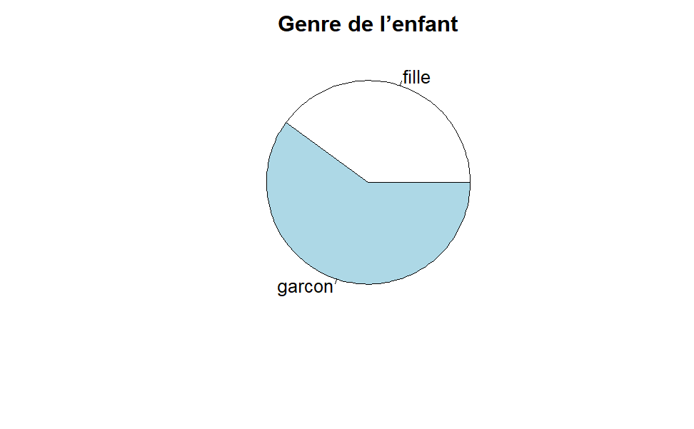

```r
pie(table(datdon$sexenf))
title(main="Genre de l’enfant")
```

Graphique (barplot):

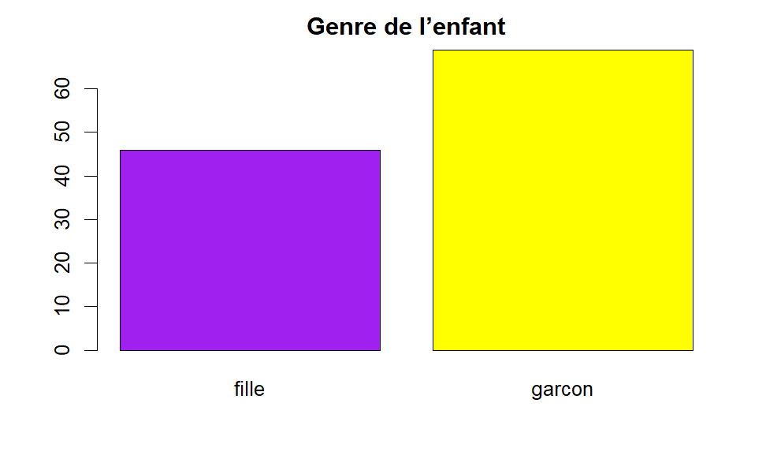

```r
barplot(table(datdon$sexenf),col=c("purple", "yellow"))
title(main="Genre de l’enfant")
```

Consommation de cigarette de la mère 10 ans plus tard :

```r
table(datdon$consm_10)
```

```
+de20cig 10a20cig   1a2cig  3a10cig   nonfum
      15       24       16        5       55
```

```r
table(datdon$consm_10)/nrow(datdon)
```

```
  +de20cig   10a20cig     1a2cig    3a10cig     nonfum
0.13043478 0.20869565 0.13913043 0.04347826 0.47826087
```

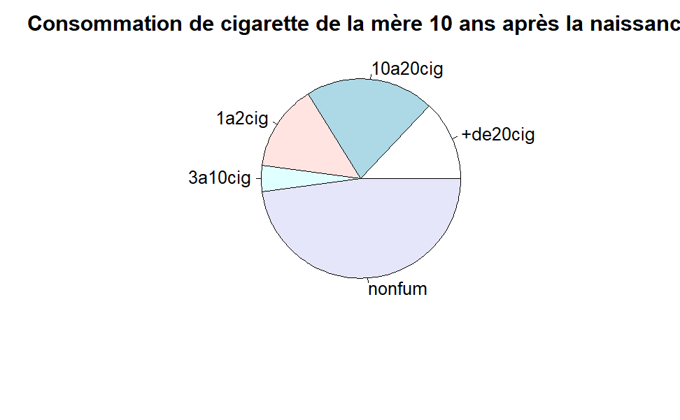

```r
pie(table(datdon$consm_10))
title(main="Consommation de cigarette de la mère 10 ans après la naissance")
```

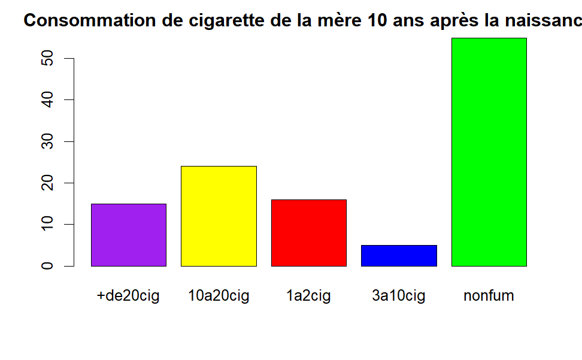

```r
barplot(table(datdon$consm_10),col=c("purple", "yellow","red","blue","green"))
title(main="Consommation de cigarette de la mère 10 ans après la naissance")
```

Consommation de cigarette du père à la naissance :

```r
table( datdon$consp_n)
```

```
+de20cig 10a20cig   1a2cig  3a10cig   nonfum
      19       46       10        4       36
```

```r
table( datdon$consp_n)/nrow(datdon)
```

```
  +de20cig   10a20cig     1a2cig    3a10cig     nonfum
0.16521739 0.40000000 0.08695652 0.03478261 0.31304348
```

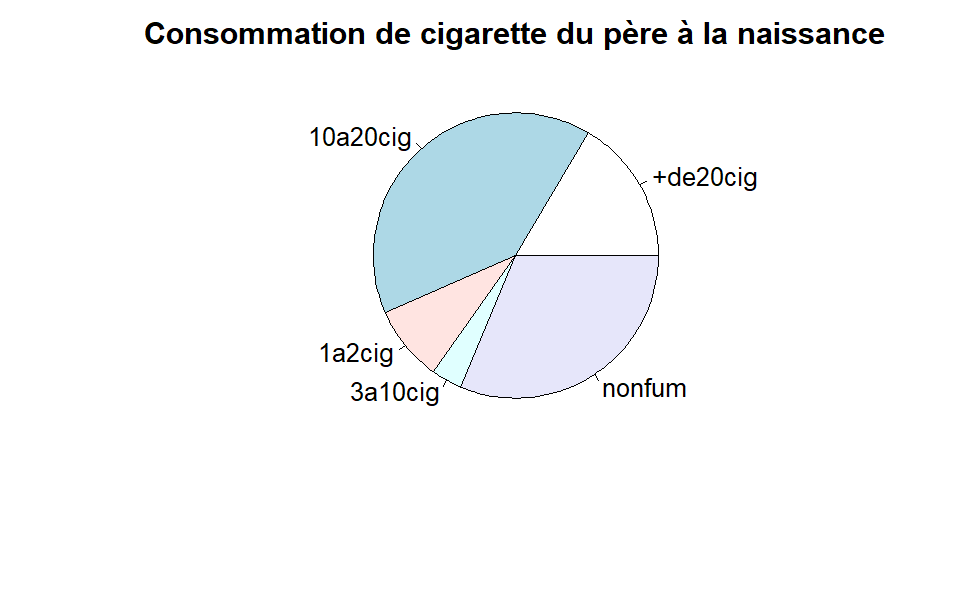

```r
pie(table(datdon$consp_n))
title(main="Consommation de cigarette du père à la naissance")
```

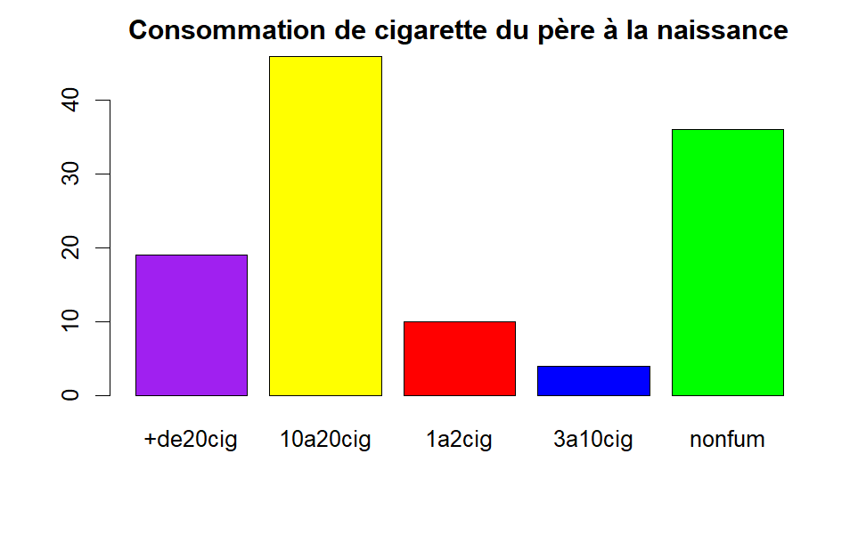

```r
barplot(table( datdon$consp_n),col=c("purple", "yellow","red","blue","green"))
title(main="Consommation de cigarette du père à la naissance")
```